# Testing MCMC Code

Gwen Eadie

21/07/2020

```r
knitr::opts_chunk$set(fig.width=10, fig.height=11)
```

## Simulated data

Now that we are quite certain that the code for the LIMEPY DF, likelihood, and priors are working properly, we will test the MCMC code.

First, let’s load the same sample data set of 500 stars, and source the appropriate functions:

```r
source("../RScripts/function_logLike_LIMEPY.r")
source("../RScripts/function_priors.r")
source("../RScripts/function_prior-wrapper.r")

# load the simulated data for testing
alldata = readRDS("../mockdata/snap_version2_dffix_2020-03-09.rds")
# get a random sample of the stars
nsamp = 500
set.seed(123)
mydata = alldata[sample(x = 1:nrow(alldata), size = nsamp, replace = FALSE), ]
```

Below are the data in $(r,v)$ space; the grey (transparent) points are all of the data, and the blue are the random subsample.

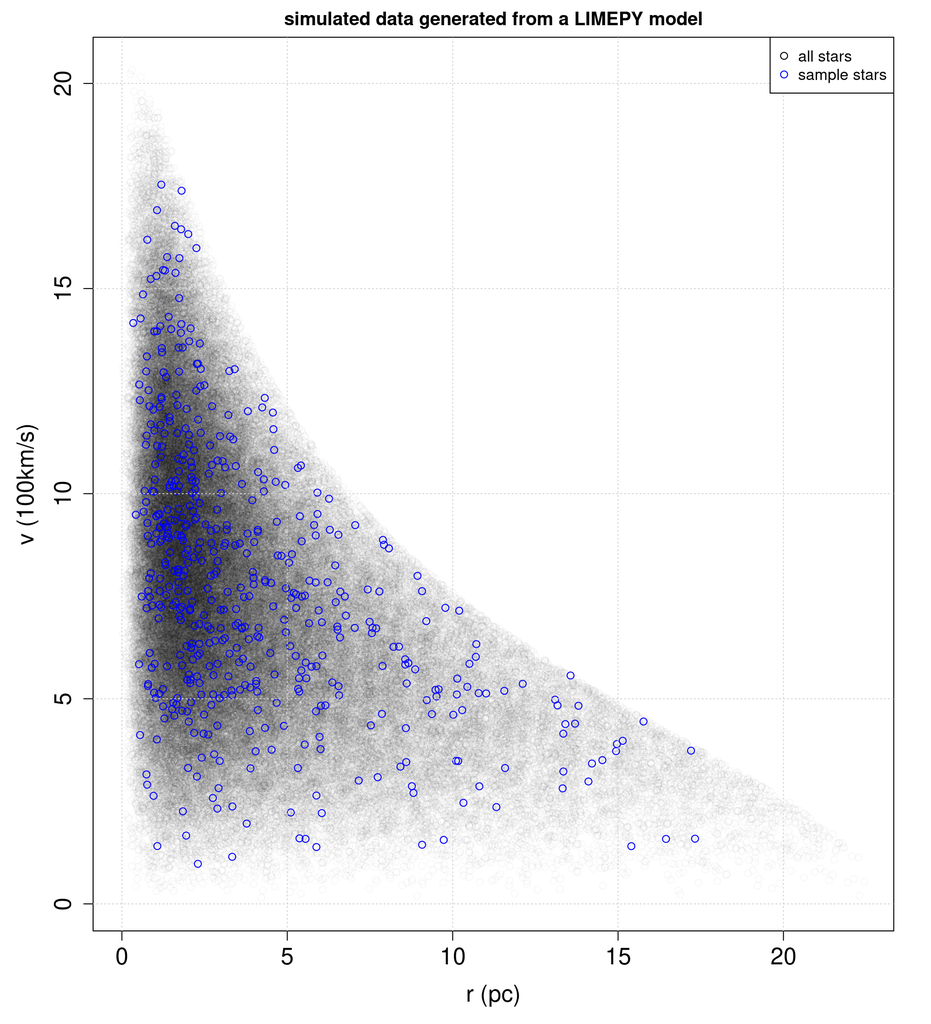

```r
par(mar=c(5,5,2,2))
plot(alldata$r, alldata$v, xlab = "r (pc)", ylab = "v (100km/s)", col=rgb(0,0,0, alpha=0.03), cex.lab=1.5, cex.axis=1.5, main = "simulated data generated from a LIMEPY model")
points(mydata$r, mydata$v, col="blue")
grid()
legend("topright", legend = c("all stars", "sample stars"), col = c("black", "blue"), pch = c(1,1))
```

## MCMC function

The function *GCmcmc()* is used to generate a Markov chain that represents the target distribution. The arguments to the fucntion are:

- init: *initial parameter values*
- logLike: *a function for the log-likelihood*
- priors: *a list of functions for the priors*
- N: *the desired number of samples*
- transform.pars: *a function to transform the parameters into different space*
- propDF: *a function for the proposal distribution*
- thinning: *by default, every accept/reject step is saved and returned (i.e. thinning = 1), but you can alternatively thin the chain as you go and only save every ith value. For example, setting thinning = 3 will make it so only every third accept/reject step is saved and returned.*
- progressBar: *logical indicating whether or not the user wants to see a progress bar while the chain is running*
- parnames: *optional character vector for the parameters (default is NULL)*
- …: *other arguments to be passed to the prior functions, propDF function, etc.*

```r
source("../RScripts/function_GCmcmc.r")
```

We use a multivariate normal for the proposal distribution. The function passed to propDF argument in GCmcmc is the following

```r
source("../RScripts/function_proposal-distribution-modelpars.r")

# show the function
mypropDF
```

```
## function (n.pars, covmat, ...)
## mvrnorm(Sigma = covmat, mu = rep(0, n.pars))
```

```r
# make a dumby covariance matrix for LIMEPY, which has 4 model parameters
covariancematrix = matrix(c(0.001,0,0,0,
                            0,0.007,0,0,
                            0,0,5e4,0,
                            0,0,0,0.02), nrow=4)

# check that mypropDF returns values which will be added to the previous parameter values
mypropDF(n.pars = 4, covmat = covariancematrix)
```

```
## [1]   -0.01762070    0.20332735 -268.02010742    0.09043783
```

```r
# covariance matrix for SPES case
SPEScovariancematrix =  matrix(c(0.001, 0, 0, 0, 0,
                            0, 1e-6, 0, 0, 0,
                            0, 0, 0.003, 0, 0,
                            0, 0, 0, 1e2, 0,
                            0, 0, 0, 0, 0.0002), nrow=5)

mypropDF(n.pars = 5, covmat = SPEScovariancematrix)
```

```
## [1]  0.035123779  0.001651915 -0.042842960  8.449042414  0.003533055
```

We are not transforming the parameter values into a different space for sampling, but we still need to pass a function to the transform.pars argument in GCmcmc, so we create a transform function that actually doesn’t transform the parameters at all. Let’s take a look and test it.

```r
source("../RScripts/function_transform-parameters.r")

# the transformation function we will use is notransform.func
notransform.func
```

```
## function (x)
## x
```

```r
# vector of parameter values
testpars = c(0.3,5,-10, 93.7)

notransform.func(x = testpars)
```

```
## [1]   0.3   5.0 -10.0  93.7
```

```r
rm(testpars)
```

The is.whole function is needed for the thinning parameter to work.

```r
source("../RScripts/function_iswhole.r")

# see how it works
is.whole(0.1)
```

```
## [1] FALSE
```

```r
is.whole(4)
```

```
## [1] TRUE
```

```r
is.whole(-Inf)
```

```
## [1] TRUE
```

```r
is.whole(NA)
```

```
## [1] FALSE
```

```r
is.whole("hello")
```

```
## [1] FALSE
```

## Using GCmcmc - LIMEPY data, LIMEPY model

We will use the optim() values as our initial starting values for running GCmcmc.

```r
initpars <- readRDS("../results/optim_LIMEPYdata_LIMEPYmodel.rds")
```

Now we are ready to run GCmcmc(). (Not run here because it takes a couple minutes).

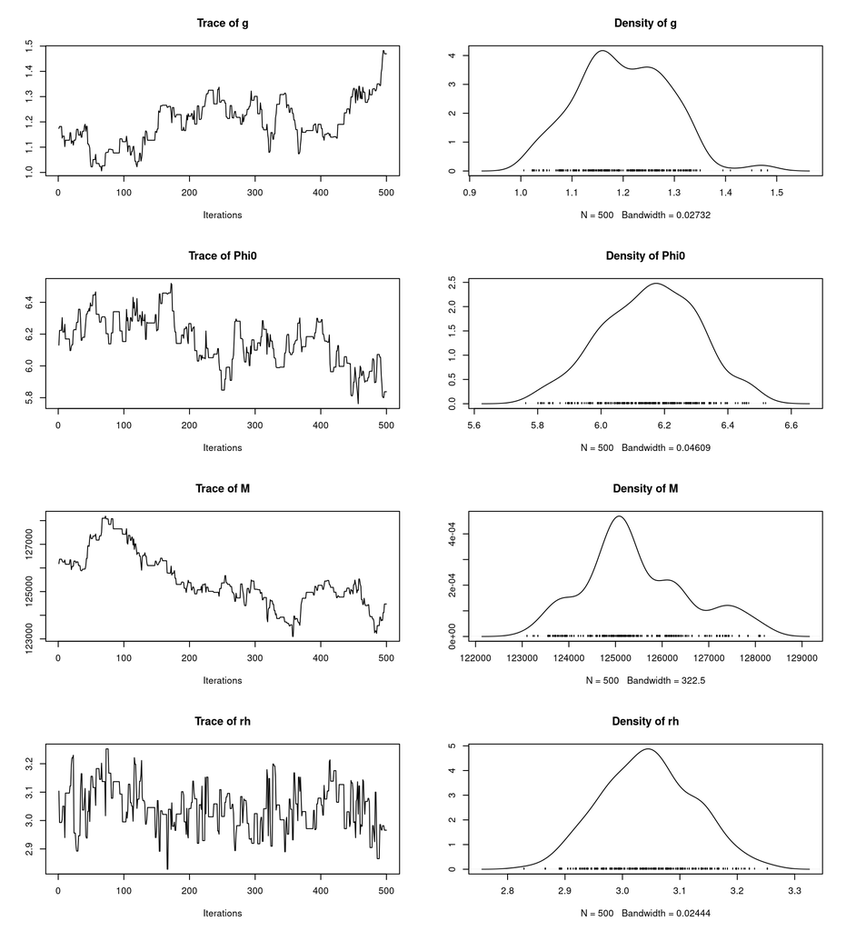

```r
# this is the run with r_h prior centered on 3.4
runinit <- readRDS("../results/initrun_LIMEPYdata_500_LIMEPYmodel_2020-07-21.rds")

# this is the run with r_h prior centered on 3.0
runinit <- readRDS("../results/initrun_LIMEPYdata_500_LIMEPYmodel_2020-08-02.rds")

# plot the preliminary results to check that things look OK
plot(runinit$chain)
```

Things seem to be working OK!

## Automated adjustment of the proposal distribution

Now we will test the function which does an automated tuning of the proposal distribution.

```r
source("../RScripts/function_adjustproposal.r")

newrun = adjustproposal(initialrun = runinit, acceptrange = c(0.26,0.4), Nsteps = 250, yourpatience = 10, mydat = mydata, logLike = logLike.limepy, priors = prior.wrapper, transform.pars = notransform.func, priorfuncs = list( singleunif.prior, singleunif.prior, normlog10M.prior, truncnorm.prior ), ppars = list( gbounds, phi0bounds, log10Mpars, rhpars ), propDF = mypropDF, parnames = c("g", "Phi_0", "M", "r_h"), n.pars=4)

str(newrun)

# what is the new proposal distribution?
newrun$newpropsd

# save output to a file
saveRDS(newrun, file = paste("../results/burnin_LIMEPYdata_500_LIMEPYmodel_", Sys.Date(), ".rds", sep="") )
```

```r
# this is the case where prior on r_h is centered on 3.4
newrun34 <- readRDS(file = "../results/burnin_LIMEPYdata_500_LIMEPYmodel_2020-07-21.rds")

# this is the case where prior on r_h is centered on 3.0
newrun <- readRDS(file = "../results/burnin_LIMEPYdata_500_LIMEPYmodel_2020-08-02.rds")

png("../results/Figures/adaptive_tuning_example.png", height=900, width=900)
plot(as.mcmc(newrun$chain), lwd=1.5, cex.main=2.5)
dev.off()
```

```r
# final run after tuning is complete
finalrun <- GCmcmc(init = newrun$newinitpars, mydat = mydata, logLike = logLike.limepy, priors = prior.wrapper, N = 5e3, transform.pars = notransform.func, priorfuncs = list( singleunif.prior, singleunif.prior, normlog10M.prior, truncnorm.prior ), ppars = list( gbounds, phi0bounds, log10Mpars, rhpars ), propDF = mypropDF, parnames = c("g", "Phi_0", "M", "r_h"), n.pars=4, covmat=newrun$newpropsd)

# save chain to file
saveRDS(object = finalrun, file = paste("../results/chain_LIMEPYdata_500_LIMEPYmodel_", Sys.Date(), ".rds", sep="") )
```

```r
# this is the run with prior on r_h centered on 3.4
finalrun34 <- readRDS("../results/chain_LIMEPYdata_500_LIMEPYmodel_2020-07-21.rds")

finalrun <- readRDS("../results/chain_LIMEPYdata_500_LIMEPYmodel_2020-08-02.rds")
summary(finalrun$chain)
```

```
##
## Iterations = 1:5000
## Thinning interval = 1
## Number of chains = 1
## Sample size per chain = 5000
##
## 1. Empirical mean and standard deviation for each variable,
##    plus standard error of the mean:
##
##            Mean        SD  Naive SE Time-series SE
## g     1.346e+00    0.1986  0.002809      1.143e-02
## Phi_0 5.979e+00    0.2842  0.004019      1.657e-02
## M     1.257e+05 3760.5577 53.182317      2.415e+02
## r_h   2.997e+00    0.1063  0.001503      6.114e-03
##
## 2. Quantiles for each variable:
##
##            2.5%       25%       50%       75%     97.5%
## g     9.970e-01 1.212e+00 1.333e+00 1.469e+00 1.784e+00
## Phi_0 5.342e+00 5.814e+00 5.998e+00 6.160e+00 6.530e+00
## M     1.183e+05 1.233e+05 1.256e+05 1.283e+05 1.332e+05
## r_h   2.792e+00 2.927e+00 2.998e+00 3.069e+00 3.203e+00
```

```r
effectiveSize(finalrun$chain)
```

```
##        g    Phi_0        M      r_h
## 301.7574 294.1829 242.4690 302.2220
```

The chain could stand to run for longer to obtain more approximately independent samples.

# Using GCmcmc - LIMEPY data, SPES model

```r
source("../RScripts/function_logLike_SPES.r")
source('../RScripts/function_prior-wrapper.r')
source("../RScripts/function_priors.r")
optimvalsSPES <- readRDS('../results/optim_LIMEPYdata_SPESmodel.rds')

initparsSPES <- optimvalsSPES$par

# hyperprior values
phi0bounds = c(1.5, 14) # assuming truncated uniform prior
Bbounds = c(0, 1) # assuming truncated uniform prior
etabounds = c(0, 1) # assuming truncated uniform prior
log10Mpars = c( 5.85, 0.6 ) # for Mpars, gaussian on log10(M)
rhpars = c(0, 30, 3.4, 0.2) # lower bound, upper bound, mean, sd
```

```r
runinitSPES <- GCmcmc(init = initparsSPES, mydat = mydata, logLike = logLike.spes, N=250, transform.pars = notransform.func, priors = prior.wrapper, priorfuncs = list( singleunif.prior, singleunif.prior, singleunif.prior, normlog10M.prior, truncnorm.prior ), ppars = list( phi0bounds, Bbounds, etabounds, log10Mpars, rhpars ), propDF = mypropDF, covmat = SPEScovariancematrix, n.pars=5, parnames = c("Phi_0", "B", "eta", "M", "r_h"), progressBar = FALSE )

plot(runinitSPES$chain)
```

[output not shown]